# BME 4550_Assignment 6

Kelsie Reinaltt

10/18/2018

# Chapter: Matrix Algebra

# Pages 146-147 Exercises

## Question 1

#### The average height of the sons is 68.68407, as shown below.

```r
mean(father.son$sheight)
```

```
## [1] 68.68407
```

## Question 2

```r
fatherht<-round(father.son$fheight,0)
fathersonht<-cbind(fatherht,father.son)

suppressMessages(library(dplyr))
sonht<-filter(fathersonht,fatherht==71) %>% select(sheight) %>% unlist
mean(sonht)
```

```
## [1] 70.54082
```

## Question 3

#### C is not a linear model because b^t is not a linear combination.

## Question 4

#### D is the correct answer because people of the same height may have different fat masses.

# Page 151 Exercises

## Question 1

#### The entry in this position is 225.

```r
X = matrix(1:1000,100,10)
X[25,3]
```

```
## [1] 225
```

## Question 2

The sum is 105.

```r
x=1:10
M<-cbind(x,2*x,3*x,4*x,5*x)
sum(M[7,])
```

```
## [1] 105
```

## Question 3

#### Just by looking at the data, I can tell that the answer is NOT D because it onoly has 2 columns. Actually creating the other matrices looks like this:

#### After looking at all of these, I can tell that the B matrix is the only one with a third column that has multiples of 3.

```r
matrix(1:60,20,3)
```

```
##       [,1] [,2] [,3]
##  [1,]    1   21   41
##  [2,]    2   22   42
##  [3,]    3   23   43
##  [4,]    4   24   44
##  [5,]    5   25   45
##  [6,]    6   26   46
##  [7,]    7   27   47
##  [8,]    8   28   48
##  [9,]    9   29   49
## [10,]   10   30   50
## [11,]   11   31   51
## [12,]   12   32   52
## [13,]   13   33   53
## [14,]   14   34   54
## [15,]   15   35   55
## [16,]   16   36   56
## [17,]   17   37   57
## [18,]   18   38   58
## [19,]   19   39   59
## [20,]   20   40   60
```

```r
matrix(1:60,20,3,byrow=TRUE)
```

```
##       [,1] [,2] [,3]
##  [1,]    1    2    3
##  [2,]    4    5    6
##  [3,]    7    8    9
##  [4,]   10   11   12
##  [5,]   13   14   15
##  [6,]   16   17   18
##  [7,]   19   20   21
##  [8,]   22   23   24
##  [9,]   25   26   27
## [10,]   28   29   30
## [11,]   31   32   33
## [12,]   34   35   36
## [13,]   37   38   39
## [14,]   40   41   42
## [15,]   43   44   45
## [16,]   46   47   48
## [17,]   49   50   51
## [18,]   52   53   54
## [19,]   55   56   57
## [20,]   58   59   60
```

```r
x=11:20; rbind(x,2*x,3*x)
```

```
##   [,1] [,2] [,3] [,4] [,5] [,6] [,7] [,8] [,9] [,10]
## x   11   12   13   14   15   16   17   18   19    20
##     22   24   26   28   30   32   34   36   38    40
##     33   36   39   42   45   48   51   54   57    60
```

```r
x=1:40; matrix(3*x,20,2)
```

```
##       [,1] [,2]
##  [1,]    3   63
##  [2,]    6   66
##  [3,]    9   69
##  [4,]   12   72
##  [5,]   15   75
##  [6,]   18   78
##  [7,]   21   81
##  [8,]   24   84
##  [9,]   27   87
## [10,]   30   90
## [11,]   33   93
## [12,]   36   96
## [13,]   39   99
## [14,]   42  102
## [15,]   45  105
## [16,]   48  108
## [17,]   51  111
## [18,]   54  114
## [19,]   57  117
## [20,]   60  120
```

# Page 157 Exercises

## Question 1

#### The second will not be equal to X. B

## Question 2

```r
3a + 4b - 5c + d = 10
2a + 2b + 2c - d = 5
a - b + 5c - 5d = 7
5a + d = 4
```

```r
X <- matrix(c(3,2,1,5,4,2,-1,0,-5,2,5,0,1,-1,-5,1),4,4)
y <- matrix(c(10,5,7,4),4,1)
solve(X)%*%y
```

```
##            [,1]
## [1,]  1.2477876
## [2,]  1.0176991
## [3,] -0.8849558
## [4,] -2.2389381
```

## Question 3

```r
a <- matrix(1:12, nrow=4)
b <- matrix(1:15, nrow=3)
```

```r
a <- matrix(1:12, nrow=4)
b <- matrix(1:15, nrow=3)
c<-a %*% b
c[3,2]
```

```
## [1] 113
```

## Question 4

```r
sum(a[3,] * b[,2])
```

```
## [1] 113
```

# Pages 165 Exercises

## Question 1

```r
X <- matrix(c(1,1,1,1,0,0,1,1),nrow=4)
rownames(X) <- c("a","a","b","b")
X
```

```
##   [,1] [,2]
## a    1    0
## a    1    0
## b    1    1
## b    1    1
```

```r
beta <- c(5, 2)
```

```r
X <- matrix(c(1,1,1,1,0,0,1,1),nrow=4)
rownames(X) <- c("a","a","b","b")

beta <- c(5, 2)

fitted = X %*% beta

fitted[ 1:2, ]
```

```
## a a
## 5 5
```

## Question 2

```r
fitted = X %*% beta
fitted[ 3:4, ]
```

```
## b b
## 7 7
```

## Question 3

```r
X <- matrix(c(1,1,1,1,1,1,0,0,1,1,0,0,0,0,0,0,1,1),nrow=6)
rownames(X) <- c("a","a","b","b","c","c")
X
```

[output not shown]

```r
beta <- c(10,3,-3)
```

```r
fitted = X %*% beta

fitted[ 3:4, ]
```

[output not shown]

## Question 4

```r
fitted = X %*% beta

fitted[ 3:4, ]
```

[output not shown]

# Chapter: Linear Models

# Pages 166-168 Questions

## Question 1

```r
B <- 1000
g = 9.8
h0 = 56.67
v0 = 0
n = 25
tt = seq(0,3.4,len=n)
tt
```

```
##  [1] 0.0000000 0.1416667 0.2833333 0.4250000 0.5666667 0.7083333 0.8500000
##  [8] 0.9916667 1.1333333 1.2750000 1.4166667 1.5583333 1.7000000 1.8416667
## [15] 1.9833333 2.1250000 2.2666667 2.4083333 2.5500000 2.6916667 2.8333333
## [22] 2.9750000 3.1166667 3.2583333 3.4000000
```

```r
y = h0 + v0 *tt - 0.5* g*tt^2 + rnorm(n,sd=1)
X = cbind(1,tt,tt^2)
A = solve(crossprod(X))%*%t(X)

betahat<-replicate(B,{
  y <- h0 + v0*tt  - 0.5*g*tt^2 + rnorm(n,sd=1)
  betahats <- A%*%y
  return(betahats[3])
})
head(betahat)
```

```
## [1] -4.712202 -5.037670 -5.244284 -5.046542 -5.064928 -5.033963
```

```r
round(mean(betahat),1)
```

```
## [1] -4.9
```

```r
sd(betahat)
```

```
## [1] 0.219
```

#### The code above finds the cross product of S by S and compares it to the known equation. The mean dsitribution of betahat displays a value of -4.9, which is essentially (A %*% y)[3] which when multiplied by -2 is 9.8. Therefore g = -2* (A %*% y)[3]

## Question 2

```r
B <- 100000
g = 9.8
h0 = 56.67
v0 = 0
n = 25
tt = seq(0,3.4,len=n)
tt
```

```
##  [1] 0.0000000 0.1416667 0.2833333 0.4250000 0.5666667 0.7083333 0.8500000
##  [8] 0.9916667 1.1333333 1.2750000 1.4166667 1.5583333 1.7000000 1.8416667
## [15] 1.9833333 2.1250000 2.2666667 2.4083333 2.5500000 2.6916667 2.8333333
## [22] 2.9750000 3.1166667 3.2583333 3.4000000
```

```r
y = h0 + v0 *tt - 0.5* g*tt^2 + rnorm(n,sd=1)
X = cbind(1,tt,tt^2)
A = solve(crossprod(X))%*%t(X)

betahat<-replicate(B,{
  y <- h0 + v0*tt  - 0.5*g*tt^2 + rnorm(n,sd=1)
  betahats <- A%*%y
  return(betahats[3])
})
head(betahat)
```

```
## [1] -4.942024 -5.110768 -5.027961 -4.992005 -4.887565 -4.753939
```

```r
round(mean(betahat),1)
```

```
## [1] -4.9
```

```r
sd(betahat)
```

```
## [1] 0.2153931
```

## Question 3

```r
x = father.son$fheight
y = father.son$sheight
n = length(y)
N <- 50
B <-10000
betahat <- replicate(B,{
  index <- sample(n,N)
  sampledat <- father.son[index,]
  x <- sampledat$fheight
  y <- sampledat$sheight
  lm(y~x)$coef
  })
betahat <- t(betahat)
sd(betahat)
```

```
## [1] 17.63936
```

## Question 4

```r
mean( (betahat[,1]-mean(betahat[,1] ))* (betahat[,2]-mean(betahat[,2])))
```

```
## [1] -1.017486
```

# Pages 177-178 Questions

## Question 1

```r
condition <- factor(c("treated","treated","treated","treated","treated","treated","control","control","control","control","control","control"))
day<- factor(c("A","A","B","B","C","C","A","A","B","B","C","C"))

table(condition,day)
```

```
##          day
## condition A B C
##   control 2 2 2
##   treated 2 2 2
```

```r
model.matrix(~day + condition)
```

```
##    (Intercept) dayB dayC conditiontreated
## 1            1    0    0                1
## 2            1    0    0                1
## 3            1    1    0                1
## 4            1    1    0                1
## 5            1    0    1                1
## 6            1    0    1                1
## 7            1    0    0                0
## 8            1    0    0                0
## 9            1    1    0                0
## 10           1    1    0                0
## 11           1    0    1                0
## 12           1    0    1                0
## attr(,"assign")
## [1] 0 1 1 2
## attr(,"contrasts")
## attr(,"contrasts")$day
## [1] "contr.treatment"
##
## attr(,"contrasts")$condition
## [1] "contr.treatment"
```

1. ~ day + condition

# Pages 183-184 Questions

## Question 1

#### the element in the first row and first column is 12.

```r
X <- cbind(rep(1,5 + 7),rep(c(0,1),c(5, 7)))
t(X) %*% (X)
```

```
##      [,1] [,2]
## [1,]   12    7
## [2,]    7    7
```

## Question 2

#### the other entries (other than element in row 1 column 1) are all the number 7

```r
X <- cbind(rep(1,5 + 7),rep(c(0,1),c(5, 7)))
t(X) %*% (X)
```

```
##      [,1] [,2]
## [1,]   12    7
## [2,]    7    7
```

# Pages 193-194 Questions

## Question 1

```r
library(UsingR)

x = father.son$fheight
y = father.son$sheight

n = length(y)
N = 50

set.seed(1)
index = sample(n,N)

sampledat = father.son[index,]
x = sampledat$fheight
y = sampledat$sheight

betahat = lm(y~x)$coef
fit <- lm(y ~ x)
fit$fitted.values
```

```
##        1        2        3        4        5        6        7        8
## 70.62707 70.36129 70.86093 68.73019 65.59181 70.55285 70.21256 68.62521
##        9       10       11       12       13       14       15       16
## 67.06729 69.64913 69.09958 71.70621 68.31598 70.57027 70.39537 70.39613
##       17       18       19       20       21       22       23       24
## 68.73977 68.98874 71.47021 72.03615 69.55975 68.15895 66.63557 71.53651
##       25       26       27       28       29       30       31       32
## 69.57083 69.71050 67.14263 70.99719 67.11046 69.04901 66.65243 67.82895
##       33       34       35       36       37       38       39       40
## 68.24209 70.70156 65.50431 67.36000 69.30065 67.94424 66.35150 71.40489
##       41       42       43       44       45       46       47       48
## 71.64301 66.81654 69.22900 69.11769 69.21793 69.69519 67.00674 68.67869
##       49       50
## 67.40752 69.28800
```

```r
e<-y-fit$fitted.values
sum(e^2)
```

```
## [1] 256.2152
```

Sum of the squared residuals is 256.2152

## Question 2

Sigma squared = SSR / 48

```r
256.2152/48
```

```
## [1] 5.337817
```

Sigma squared is equivalent to 5.337817

## Question 3

```r
X = cbind(rep(1,N), x)
solve(t(X) %*% X)[1,1]
```

```
## [1] 11.30275
```

## Question 4

```r
sqrt(diag(solve(t(X) %*% X)) * (256.2152/48))
```

```
##                   x
## 7.7673678 0.1141966
```

#### The standard error for the slope is 0.1141966.

# Pages 224-226 Questions

## Question 1

```r
species <- factor(c("A","A","B","B"))
condition <- factor(c("control","treated","control","treated"))
model.matrix(~ species + condition)
```

```
##   (Intercept) speciesB conditiontreated
## 1           1        0                0
## 2           1        0                1
## 3           1        1                0
## 4           1        1                1
## attr(,"assign")
## [1] 0 1 2
## attr(,"contrasts")
## attr(,"contrasts")$species
## [1] "contr.treatment"
##
## attr(,"contrasts")$condition
## [1] "contr.treatment"
```

```r
y = rnorm(4)

fit = lm(y ~ species + condition)

contrast(fit, list(species="B",condition="control"), list(species="A",condition="treated"))$X
```

```
##   (Intercept) speciesB conditiontreated
## 1           0        1               -1
## attr(,"assign")
## [1] 0 1 2
## attr(,"contrasts")
## attr(,"contrasts")$species
## [1] "contr.treatment"
##
## attr(,"contrasts")$condition
## [1] "contr.treatment"
```

## Question 2

```r
url <- "https://raw.githubusercontent.com/genomicsclass/dagdata/master/inst/extdata/spider_wolff_gorb_2013.csv"
filename <- "spider_wolff_gorb_2013.csv"
library(downloader)
if (!file.exists(filename)) download(url, filename)
spider <- read.csv("spider_wolff_gorb_2013.csv", skip=1)
fitTL <- lm(friction ~ type + leg, data=spider)
summary(fitTL)
```

```
##
## Call:
## lm(formula = friction ~ type + leg, data = spider)
##
## Residuals:
##      Min       1Q   Median       3Q      Max
## -0.46392 -0.13441 -0.00525  0.10547  0.69509
##
## Coefficients:
##             Estimate Std. Error t value Pr(>|t|)
## (Intercept)  1.05392    0.02816  37.426  < 2e-16 ***
## typepush    -0.77901    0.02482 -31.380  < 2e-16 ***
## legL2        0.17192    0.04569   3.763 0.000205 ***
## legL3        0.16049    0.03251   4.937 1.37e-06 ***
## legL4        0.28134    0.03438   8.183 1.01e-14 ***
## ---
## Signif. codes:  0 '***' 0.001 '**' 0.01 '*' 0.05 '.' 0.1 ' ' 1
##
## Residual standard error: 0.2084 on 277 degrees of freedom
## Multiple R-squared:  0.7916, Adjusted R-squared:  0.7886
## F-statistic:   263 on 4 and 277 DF,  p-value: < 2.2e-16
```

```r
(coefs <- coef(fitTL))
```

```
## (Intercept)    typepush       legL2       legL3       legL4
##   1.0539153  -0.7790071   0.1719216   0.1604921   0.2813382
```

```r
L4vsL2 <- contrast(fitTL,list(leg="L4",type="pull"),list(leg="L2",type="pull"))
L4vsL2$testStat
```

```
##        1
## 2.451974
```

#### t = 2.451974

## Question 3

```r
X <- model.matrix(~ type + leg, data=spider)
(Sigma <- sum(fitTL$residuals^2)/(nrow(X) - ncol(X)) * solve(t(X) %*% X))
```

```
##               (Intercept)      typepush         legL2         legL3
## (Intercept)  0.0007929832 -3.081306e-04 -0.0006389179 -0.0006389179
## typepush    -0.0003081306  6.162612e-04  0.0000000000  0.0000000000
## legL2       -0.0006389179 -6.439411e-20  0.0020871318  0.0006389179
## legL3       -0.0006389179 -6.439411e-20  0.0006389179  0.0010566719
## legL4       -0.0006389179 -1.191291e-19  0.0006389179  0.0006389179
##                     legL4
## (Intercept) -0.0006389179
## typepush     0.0000000000
## legL2        0.0006389179
## legL3        0.0006389179
## legL4        0.0011819981
```

```r
C <- matrix(c(0,0,-1,0,1),1,5)
Sigma[3,5]
```

```
## [1] 0.0006389179
```

Cov(beta-hat_L4, beta-hat_L2) = 0.0006389179

## Question 4

```r
spider$log2friction <- log2(spider$friction)
head(spider)
```

```
##   leg type friction log2friction
## 1  L1 pull     0.90   -0.1520031
## 2  L1 pull     0.91   -0.1360615
## 3  L1 pull     0.86   -0.2175914
## 4  L1 pull     0.85   -0.2344653
## 5  L1 pull     0.80   -0.3219281
## 6  L1 pull     0.87   -0.2009127
```

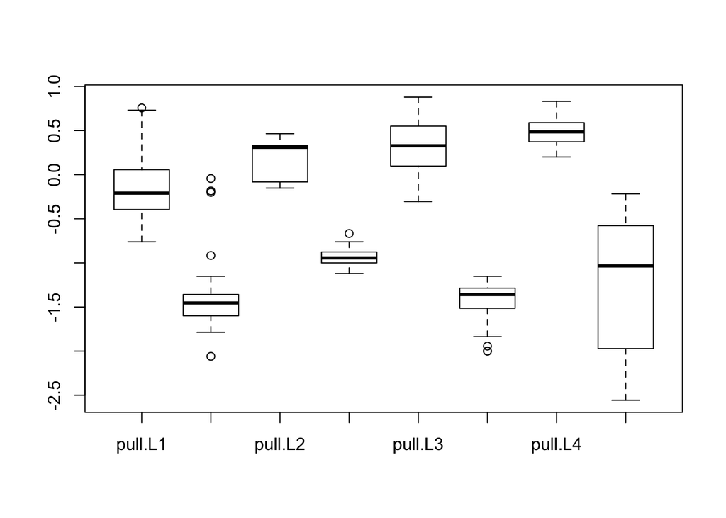

```r
boxplot(log2friction ~ type*leg, data=spider)
```

```r
fitln <- lm(log2friction ~ type*leg, data=spider)
summary(fitln)
```

```
##
## Call:
## lm(formula = log2friction ~ type * leg, data = spider)
##
## Residuals:
##      Min       1Q   Median       3Q      Max
## -1.35902 -0.19193  0.00596  0.16315  1.33090
##
## Coefficients:
##                Estimate Std. Error t value Pr(>|t|)
## (Intercept)    -0.16828    0.06613  -2.545 0.011487 *
## typepush       -1.20656    0.09352 -12.901  < 2e-16 ***
## legL2           0.34681    0.11952   2.902 0.004014 **
## legL3           0.48999    0.08505   5.762 2.24e-08 ***
## legL4           0.64668    0.08995   7.189 6.20e-12 ***
## typepush:legL2  0.09967    0.16903   0.590 0.555906
## typepush:legL3 -0.54075    0.12027  -4.496 1.02e-05 ***
## typepush:legL4 -0.46920    0.12721  -3.689 0.000272 ***
## ---
## Signif. codes:  0 '***' 0.001 '**' 0.01 '*' 0.05 '.' 0.1 ' ' 1
##
## Residual standard error: 0.3856 on 274 degrees of freedom
## Multiple R-squared:  0.8125, Adjusted R-squared:  0.8077
## F-statistic: 169.6 on 7 and 274 DF,  p-value: < 2.2e-16
```

#### Typepush-legL4 has a tstatistic value of -3.689. As this is a large value, we reject the null hypothesis that push vs. pull effect on

#### log2(friction) is the same in L4 as in L1.

## Question 5

```r
anova(fitln)
```

```
## Analysis of Variance Table
##
## Response: log2friction
##            Df  Sum Sq Mean Sq  F value    Pr(>F)
## type        1 164.709 164.709 1107.714 < 2.2e-16 ***
## leg         3   7.065   2.355   15.838 1.589e-09 ***
## type:leg    3   4.774   1.591   10.701 1.130e-06 ***
## Residuals 274  40.742   0.149
## ---
## Signif. codes:  0 '***' 0.001 '**' 0.01 '*' 0.05 '.' 0.1 ' ' 1
```

#### The f-statistic is 10.701. Thus we reject the null hypothesis that the push vs. pull effect on log2(friction) is the same for all leg pairs.

## Question 6

```r
contrast(fitln, list(type="pull",leg="L2"), list(type="pull",leg="L1"))
```

```
## lm model parameter contrast
##
##   Contrast      S.E.     Lower     Upper   t  df Pr(>|t|)
##  0.3468125 0.1195246 0.1115092 0.5821157 2.9 274    0.004
```

```r
coef(fitln)["legL2"]
```

```
##     legL2
## 0.3468125
```

#### The L2 vs L1 estimate for pull is 0.3468125

## Question 7

```r
contrast(fitln, list(type="push",leg="L2"), list(type="push",leg="L1"))
```

```
## lm model parameter contrast
##
##   Contrast      S.E.    Lower     Upper    t  df Pr(>|t|)
##  0.4464843 0.1195246 0.211181 0.6817875 3.74 274    2e-04
```

```r
coef(fitln)["legL2"] + coef(fitln)["typepush:legL2"]
```

```
##     legL2
## 0.4464843
```

#### The L2 vs L1 estimate for push is 0.4464843

# Pages 231-232 Questions

## Question 1

```r
m = matrix(c(1,1,1,1,0,0,1,1,0,1,0,1,0,0,0,1),4,4)
m
```

```
##      [,1] [,2] [,3] [,4]
## [1,]    1    0    0    0
## [2,]    1    0    1    0
## [3,]    1    1    0    0
## [4,]    1    1    1    1
```

```r
qr(m)$rank
```

```
## [1] 4
```

#### As the rank of the E matrix is equal to the number of columns, so all of the columns are independent.Therefore E does not have the issue of collinearity

## Question 2

```r
sex <- factor(rep(c("female","male"),each=4))
trt <- factor(c("A","A","B","B","C","C","D","D"))

X <- model.matrix( ~ sex + trt)

qr(X)$rank
```

```
## [1] 4
```

```r
Y <- 1:8

makeYstar <- function(a,b) Y - X[,2] * a - X[,5] * b


fitTheRest <- function(a,b) {
  Ystar <- makeYstar(a,b)
  Xrest <- X[,-c(2,5)]
  betarest <- solve(t(Xrest) %*% Xrest) %*% t(Xrest) %*% Ystar
  residuals <- Ystar - Xrest %*% betarest
  sum(residuals^2)
}
fitTheRest(1,2)
```

```
## [1] 11
```

#### Sum of squared residuals when male coefficient is 1, and the D coefficient is 2, and the other coefficients are fit using the linear model solution = 11.

## Question 3

```r
expand.grid(1:3,1:3)
```

```
##   Var1 Var2
## 1    1    1
## 2    2    1
## 3    3    1
## 4    1    2
## 5    2    2
## 6    3    2
## 7    1    3
## 8    2    3
## 9    3    3
```

```r
betas = expand.grid(-2:8,-2:8)
rss = apply(betas,1,function(x) fitTheRest(x[1],x[2]))
themin= min(rss)
betas[which(rss==themin),]
```

```
##     Var1 Var2
## 11     8   -2
## 21     7   -1
## 31     6    0
## 41     5    1
## 51     4    2
## 61     3    3
## 71     2    4
## 81     1    5
## 91     0    6
## 101   -1    7
## 111   -2    8
```

#### As there is no single minimum, all of the above are the smallest Least Square Residuals.